# North West Atlantic Stomach Data

Can’t see any typos so I’ll assume that I can go ahead and look for any numerical errors. I’ll start off with going from left to right in the numeric columns, alternating between NWA73_80 and NWA81_90 on each column comparison.

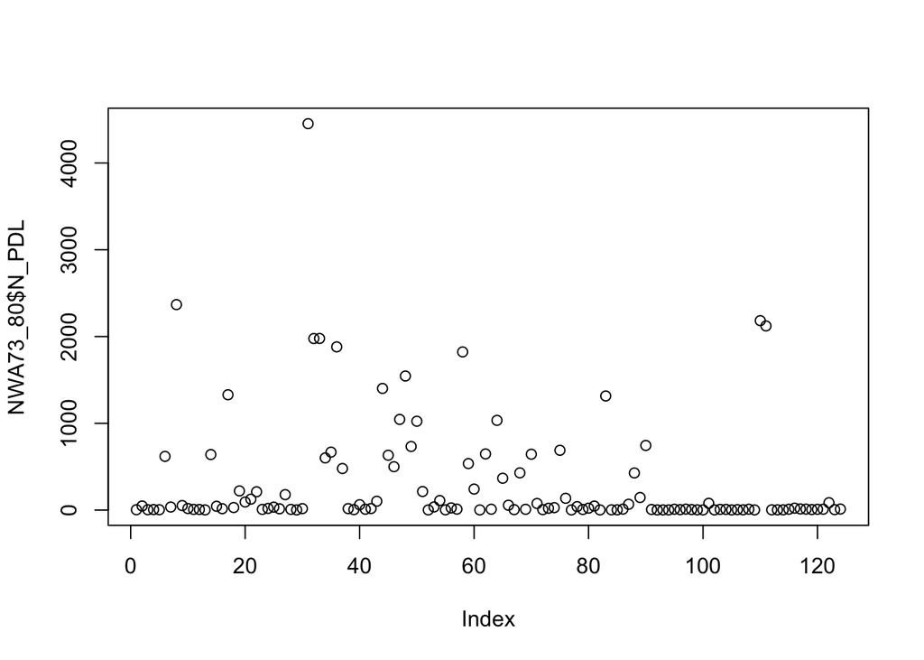

```r
plot(NWA73_80$N_PDL)
```

Going to look at the summaries for the minimum, mean and max predator lengths so I can remove or alter any observations that don’t fit the data trend.

```r
summary(NWA73_80$MIN_PDL)
```

```
##    Min. 1st Qu.  Median    Mean 3rd Qu.    Max.
##    2.00    7.75   14.00   21.86   24.00  213.00
```

```r
summary(NWA81_90$MIN_PDL)
```

```
##    Min. 1st Qu.  Median    Mean 3rd Qu.    Max.
##     2.0     7.0    25.0   804.6   419.8 19620.0
```

```r
summary(NWA73_80$MAX_PDL)
```

```
##    Min. 1st Qu.  Median    Mean 3rd Qu.    Max.
##    6.00   24.00   41.50   56.34   80.50  246.00
```

```r
summary(NWA81_90$MAX_PDL)
```

```
##    Min. 1st Qu.  Median    Mean 3rd Qu.    Max.
##   14.00   33.00   52.50   67.89  104.75  220.00
```

```r
summary(NWA73_80$MEAN_PDL)
```

```
##    Min. 1st Qu.  Median    Mean 3rd Qu.    Max.
##    5.25   18.07   26.91   37.12   49.16  233.75
```

```r
summary(NWA81_90$MEAN_PDL)
```

```
##    Min. 1st Qu.  Median    Mean 3rd Qu.    Max.
##   13.70   24.01   32.00   43.94   57.69  146.67
```

It looks like some values in the minimum column have been multiplied by 10 or 100 looking at the 3rd Quartile and Max value for the 1981-90 data set in comparison to the MAX_PDL, as common sense tells us that each value in the output of the summary function should be greater for the MAX_PDL than the MIN_PDL. In the following block of code I will divide the values in MIN_PDL for the 1981-90 period by a suitable value so it fits in with the dataset.

```r
NWA81_90[ 5, 4] <- NWA81_90[ 5, 4]/100
NWA81_90[ 11, 4] <- NWA81_90[ 11, 4]/100
NWA81_90[ 12, 4] <- NWA81_90[ 12, 4]/10
NWA81_90[ 14, 4] <- NWA81_90[ 14, 4]/100
NWA81_90[ 15, 4] <- NWA81_90[ 15, 4]/10
NWA81_90[ 16, 4] <- NWA81_90[ 16, 4]/100
NWA81_90[ 18, 4] <- NWA81_90[ 18, 4]/100
NWA81_90[ 19, 4] <- NWA81_90[ 19, 4]/10
NWA81_90[ 20, 4] <- NWA81_90[ 20, 4]/10
NWA81_90[ 24, 4] <- NWA81_90[ 24, 4]/10
NWA81_90[ 25, 4] <- NWA81_90[ 25, 4]/1000
NWA81_90[ 26, 4] <- NWA81_90[ 26, 4]/100
NWA81_90[ 26, 4] <- NWA81_90[ 26, 4]/10
NWA81_90[ 27, 4] <- NWA81_90[ 27, 4]/100
NWA81_90[ 28, 4] <- NWA81_90[ 28, 4]/100
NWA81_90[ 29, 4] <- NWA81_90[ 29, 4]/1000
NWA81_90[ 30, 4] <- NWA81_90[ 30, 4]/1000
NWA81_90[ 31, 4] <- NWA81_90[ 31, 4]/100
NWA81_90[ 35, 4] <- NWA81_90[ 35, 4]/10
NWA81_90[ 36, 4] <- NWA81_90[ 36, 4]/10
NWA81_90[ 37, 4] <- NWA81_90[ 37, 4]/100
NWA81_90[ 38, 4] <- NWA81_90[ 38, 4]/100
NWA81_90[ 39, 4] <- NWA81_90[ 39, 4]/100
NWA81_90[ 40, 4] <- NWA81_90[ 40, 4]/100
NWA81_90[ 41, 4] <- NWA81_90[ 41, 4]/10
NWA81_90[ 42, 4] <- NWA81_90[ 42, 4]/100
NWA81_90[ 43, 4] <- NWA81_90[ 43, 4]/10
NWA81_90[ 45, 4] <- NWA81_90[ 45, 4]/10
NWA81_90[ 49, 4] <- NWA81_90[ 49, 4]/10
NWA81_90[ 51, 4] <- NWA81_90[ 51, 4]/100
NWA81_90[ 52, 4] <- NWA81_90[ 52, 4]/10
NWA81_90[ 54, 4] <- NWA81_90[ 54, 4]/10
NWA81_90[ 55, 4] <- NWA81_90[ 55, 4]/100
NWA81_90[ 56, 4] <- NWA81_90[ 56, 4]/1000
NWA81_90[ 58, 4] <- NWA81_90[ 58, 4]/10
NWA81_90[ 59, 4] <- NWA81_90[ 59, 4]/100
NWA81_90[ 62, 4] <- NWA81_90[ 62, 4]/100
NWA81_90[ 63, 4] <- NWA81_90[ 63, 4]/100
NWA81_90[ 64, 4] <- NWA81_90[ 64, 4]/10
NWA81_90[ 73, 4] <- NWA81_90[ 73, 4]/10
NWA81_90[ 74, 4] <- NWA81_90[ 74, 4]/100
NWA81_90[ 83, 4] <- NWA81_90[ 83, 4]/10
NWA81_90[ 82, 4] <- NWA81_90[ 82, 4]*10
NWA81_90[ 85, 4] <- NWA81_90[ 85, 4]*10
NWA81_90[ 87, 4] <- NWA81_90[ 87, 4]/100
NWA81_90[ 88, 4] <- NWA81_90[ 88, 4]/100
NWA81_90[ 89, 4] <- NWA81_90[ 89, 4]*10
NWA81_90[ 90, 4] <- NWA81_90[ 90, 4]*10
NWA81_90[ 91, 4] <- NWA81_90[ 91, 4]*10
NWA81_90[ 92, 4] <- NWA81_90[ 92, 4]*10
NWA81_90[ 100, 4] <- NWA81_90[ 100, 4]*10
NWA81_90[ 101, 4] <- NWA81_90[ 101, 4]*10
```